# Processing for Astronomical Data

```python
import autoe
```

### Open a FITS File

This function is based on the [astropy](https://www.astropy.org) library which is used open a FITS file and return an image in the form of a 2D [numpy](https://numpy.org) array.

```python
image = autoe.open_fits_file('http://data.astropy.org/tutorials/FITS-images/HorseHead.fits')
```

### Print Details of Image

- This basic functionality is used to print details of the image including: data, type, type, shape, dim, size, standard deviation. Along with displaying the image using the [matplotlib](https://matplotlib.org) library.

```
==== Image Data ====
Image data:
[[ 7201  6642  6642 ...  9498  9498 10057]
 [ 6642  6363  6642 ... 10057 10616 10616]
 [ 6922  6642  6922 ... 10337 11175 10616]
 ...
 [ 5412  5132  5412 ... 13000 12580 12021]
 [ 5796  5517  5796 ... 12546 12546 11987]
 [ 5796  5796  6076 ... 11987 12546 12546]]
Image type: <class 'numpy.ndarray'>
Image dtype: >i2
Image shape: (893, 891)
Image ndim: 2
Image size: 795663
Standard Deviation 3032.3927542049046
```

[figure not shown]

```python
autoe.print_img_details(image)
```

### Extract Square Samples

This function extract square samples from the original image. It reshapes the 2D image into a collection of square samples by slicing the image into the desired sample square length. This function is based on the [SKLearn](https://scikit-learn.org/).

```python
samples = autoe.extract_samples(image, 100)
```

### Reconstruct sliced samples to original image

This function takes the sliced images and reconstructs them back to the original image.

```python
reconstruct = autoe.reconstruct_samples(samples, image.shape)
```

### Reconstruct slices samples with standard deviation

This function is similar to the function above however the difference is that it calculates the standard devitation of each square and reconstructs an image based on that. This is similar to creating a heatmap to find where activity is within the image.

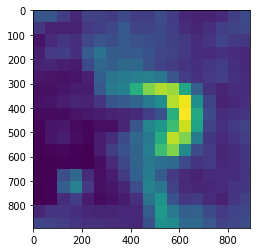

```python
reconstruct_stdev = autoe.calculate_stdev(samples, image.shape)
```

### Merge original image and standard devitation squares

This function takes in two image and displays merged image. This is useful to use with the original image and the reconstructed image with the standard deviation to see which area of the astronomical image has the more activity.

```python
autoe.merge_images(image, reconstruct_stdev)
```

[output not shown]

### Slicing animation

This function illustrates the image slicing activity and the prints out the standard deviation of each square.

```python
autoe.slicing_animation(image, 100)
```

[output not shown]